# CHD2 Cortical Brain Organoids Day50 - DEGs overlap with NDD genes

Oliviero Leonardi

January 10, 2025

### Overlap Analysis between NDD genes and DEGs in Day50 Cortical Brain Organoids

**knowledge bases:**

- **SFARI**
- **DECIPHER**

```r
library(GeneOverlap)
library(tidyr)
library(dplyr)
library(ggplot2)
```

## 1. Environment Set Up

```r
for (i in 1:length(params))
  print(paste('Parameter:', names(params)[i], ' - Value:', params[[i]], '- Class:', class(params[[i]])))
```

```
## [1] "Parameter: Dataset  - Value: CHD2_iPSCs_and_organoids_PublicRepo - Class: character"
## [1] "Parameter: DEAList_HT  - Value: /group/testa/Project/CHD2/BulkRNAseq/results/PublicRepo/2.DEA/day50/Output/Savings/day50CbO.DEAList_HT.rds - Class: character"
## [1] "Parameter: DEAList_AR  - Value: /group/testa/Project/CHD2/BulkRNAseq/results/PublicRepo/2.DEA/day50/Output/Savings/day50CbO.DEAList_AR.rds - Class: character"
## [1] "Parameter: GeneSets  - Value: /group/testa/Project/CHD2/BulkRNAseq/data/GeneSets/NDDoverlaps/ - Class: character"
## [1] "Parameter: SavingFolder  - Value: /group/testa/Project/CHD2/BulkRNAseq/results/PublicRepo/7.NDDOverlap/Output/Savings/ - Class: character"
## [1] "Parameter: FiguresFolder  - Value: /group/testa/Project/CHD2/BulkRNAseq/results/PublicRepo/7.NDDOverlap/Output/Figures/ - Class: character"
## [1] "Parameter: FDRthr  - Value: 0.05 - Class: numeric"
## [1] "Parameter: logFCthr  - Value: 1.5 - Class: numeric"
```

## **DEGs are thresholded for Overlap Analysis:**

### **FDR threshold: 0.05**

### **LogFC threshold: 1.5**

```r
logFCthr <- params$logFCthr
FDRthr <- params$FDRthr
```

## 2. Data Upload

### DEA

```r
DEAList_HT <- readRDS(params$DEAList_HT)
DEAList_AR <- readRDS(params$DEAList_AR)

DEAList_HT
```

```
## $dds
## class: DESeqDataSet
## dim: 17673 14
## metadata(1): version
## assays(4): counts mu H cooks
## rownames(17673): TSPAN6 TNMD ... NPBWR1 PDCD6-AHRR
## rowData names(47): Gene EnsGene ... deviance maxCooks
## colnames(14): OLE_010 OLE_011 ... OLE_048 OLE_049
## colData names(12): SampleNumber SampleID_GU ... lib.size sizeFactor
##
## $HT
## $HT$res
## log2 fold change (MLE): Genotype HT vs WT
## Wald test p-value: Genotype HT vs WT
## DataFrame with 17673 rows and 6 columns
##                baseMean log2FoldChange     lfcSE      stat      pvalue       padj
##               <numeric>      <numeric> <numeric> <numeric>   <numeric>  <numeric>
## TSPAN6       1022.69733      -0.113571 0.1088076  -1.04377 0.296589803 0.46422519
## TNMD            7.74747       2.675421 0.9693185   2.76011 0.005778269 0.02123805
## DPM1          566.77011      -0.122239 0.0911219  -1.34149 0.179763013 0.32447589
## SCYL3         326.10166      -0.120111 0.0949914  -1.26444 0.206072526 0.35935167
## C1orf112      220.67316      -0.487005 0.1295828  -3.75825 0.000171104 0.00106128
## ...                 ...            ...       ...       ...         ...        ...
## LINC01949       6.08511      -0.533526  0.608744 -0.876439    0.380792   0.553295
## C8orf44       175.25242      -0.221174  0.171898 -1.286660    0.198213   0.348982
## C8orf44-SGK3   11.64862      -0.974339  0.604945 -1.610624    0.107262   0.221581
## NPBWR1          3.66410       1.095843  1.038395  1.055324    0.291277   0.458602
## PDCD6-AHRR     40.02742       1.661350  2.417512  0.687215    0.491947   0.657452
##
## $HT$DEGs
##              baseMean log2FoldChange      lfcSE       stat       pvalue         padj
## TNMD         7.747472      2.6754212 0.96931846   2.760106 5.778269e-03 2.123805e-02
## STPG1       65.812213     -0.6235108 0.21717451  -2.871013 4.091587e-03 1.599170e-02
## HS3ST1      14.255409      3.0124979 0.81654757   3.689311 2.248622e-04 1.341895e-03
## HECW1      487.012064      0.8998175 0.14022555   6.416930 1.390502e-10 3.824984e-09
## TMEM176A    25.491782     -2.0059545 0.72412383  -2.770182 5.602504e-03 2.071062e-02
## KLHL13     805.517717      0.8119393 0.14104425   5.756628 8.581068e-09 1.547450e-07
## CYP26B1   2066.779889      1.3435384 0.35285664   3.807604 1.403197e-04 8.936937e-04
## PDK4        24.639527     -1.9826830 0.55612120  -3.565200 3.635795e-04 2.038624e-03
## SLC25A13   685.642382     -0.9047285 0.13729488  -6.589674 4.407920e-11 1.337815e-09
```

[output cut: 365 more lines]

```
## HNRNPM    4415.756986     -0.6089637 0.09319301 1.563863e-12 6.132763e-11
## SLC7A4      11.454227     -4.6046071 0.88946172 3.161345e-09 6.392779e-08
## SEZ6L     2049.299359      0.9889352 0.29399746 2.567680e-05 2.000804e-04
## LGALS1      71.686130      1.2568887 0.49244825 1.011132e-04 6.698365e-04
## SOX10       12.272518      0.8163050 1.18557450 2.940419e-03 1.206733e-02
## CENPM      118.687481     -0.7672282 0.21567317 1.202597e-05 1.017130e-04
## SEPTIN3  12294.134164      0.6614896 0.08131416 1.261031e-17 9.756102e-16
## SLC5A4       4.345687      0.7348124 0.91266436 4.032553e-03 1.581447e-02
## TIMP3      275.667631      1.0044593 0.42216763 3.033876e-04 1.743850e-03
## MCM5       955.075706     -0.8794455 0.17585069 3.888773e-08 5.932434e-07
## TSPO        49.359249     -1.2938861 0.32372038 1.908296e-06 1.994618e-05
## RASD2       78.213329      0.6901931 0.46245857 4.073060e-03 1.593366e-02
## APOL4       20.507939      1.5797718 0.59197682 2.598091e-05 2.017677e-04
## PNPLA3     322.158923      0.9305688 0.08838558 1.279315e-26 2.052827e-24
##  [ reached 'max' / getOption("max.print") -- omitted 1544 rows ]
```

```r
DEAList_AR
```

```
## $dds
## class: DESeqDataSet
## dim: 17673 14
## metadata(1): version
## assays(4): counts mu H cooks
## rownames(17673): TSPAN6 TNMD ... NPBWR1 PDCD6-AHRR
## rowData names(47): Gene EnsGene ... deviance maxCooks
## colnames(14): OLE_010 OLE_011 ... OLE_048 OLE_049
## colData names(12): SampleNumber SampleID_GU ... lib.size sizeFactor
##
## $AR
## $AR$res
## log2 fold change (MLE): Genotype AR vs WT
## Wald test p-value: Genotype AR vs WT
## DataFrame with 17673 rows and 6 columns
##                baseMean log2FoldChange     lfcSE       stat    pvalue      padj
##               <numeric>      <numeric> <numeric>  <numeric> <numeric> <numeric>
## TSPAN6       1022.69733       0.244252 0.1192471   2.048285 0.0405320 0.1526386
## TNMD            7.74747       0.671671 1.1834179   0.567569 0.5703278        NA
## DPM1          566.77011       0.181490 0.0999239   1.816287 0.0693263 0.2169459
## SCYL3         326.10166      -0.077452 0.1058136  -0.731967 0.4641889 0.6804306
## C1orf112      220.67316       0.333052 0.1356996   2.454331 0.0141147 0.0735165
## ...                 ...            ...       ...        ...       ...       ...
## LINC01949       6.08511      -0.435760  0.705506 -0.6176550  0.536803        NA
## C8orf44       175.25242       0.217527  0.189150  1.1500194  0.250136  0.479973
## C8orf44-SGK3   11.64862      -0.676492  0.684428 -0.9884044  0.322955        NA
## NPBWR1          3.66410      -0.603128  1.068740 -0.5643352  0.572526        NA
## PDCD6-AHRR     40.02742       0.259541  2.661601  0.0975133  0.922319  0.962337
##
## $AR$DEGs
##            baseMean log2FoldChange      lfcSE       stat       pvalue         padj
## HECW1     487.01206     -0.6907292 0.15649437  -4.413764 1.015888e-05 3.214922e-04
## CYP26B1  2066.77989     -1.7743093 0.39521143  -4.489519 7.138414e-06 2.456187e-04
## SLC7A2     71.45486      0.8495051 0.21178343   4.011197 6.041161e-05 1.315440e-03
## PRKAR2B  2149.63295     -0.6062280 0.10519453  -5.762923 8.266931e-09 8.676709e-07
## ITGA3     260.50731     -0.7856492 0.18879742  -4.161334 3.163933e-05 7.890018e-04
## TAC1      182.89786     -1.2284544 0.33653780  -3.650272 2.619630e-04 4.048494e-03
## MAP3K9   1045.22555     -0.5908176 0.09412563  -6.276905 3.453788e-10 5.927920e-08
## SYN1      721.45461     -0.6133381 0.12050585  -5.089696 3.586379e-07 2.051831e-05
## TFAP2B   5409.28759     -0.6033988 0.22197892  -2.718271 6.562415e-03 4.287464e-02
```

[output cut: 365 more lines]

```
## PCDHA5        81.91158     -0.7255426 0.23454020 7.708863e-06 2.623469e-04
## PCDHA4      1036.58113     -0.9736976 0.10501985 4.476157e-22 7.255850e-19
## PCDHA2       319.06314     -4.6839904 0.35063185 2.270822e-41 1.656451e-37
## TRIM71      1221.68580      0.7256423 0.29858037 4.276687e-05 1.009589e-03
## XKR4         883.11247     -0.6476978 0.14470422 5.020401e-08 3.937776e-06
## MIR219A2HG   311.47484      0.6971330 0.25104478 2.057505e-05 5.695814e-04
## MEG3        7371.75115     -9.0930050 0.60523993 3.161204e-52 4.611880e-48
## SKOR2        374.49058     -2.6468019 0.81651045 1.302233e-07 8.481376e-06
## GPC1-AS1      53.44658     -0.6426524 0.31171542 1.382371e-04 2.511507e-03
## MEG9          29.44203     -7.0978054 0.96256893 7.462871e-15 4.948901e-12
## LINC02470     47.22127     -7.5383128 1.09173670 2.128254e-13 1.063141e-10
## MEG8          62.24677     -2.2602300 0.49687695 2.029972e-10 3.641494e-08
## LINC01515     75.01665     -3.0635122 0.40975071 5.632265e-15 4.324690e-12
## FEZF1-AS1     31.11261      0.8876431 1.09961696 9.187024e-05 1.833509e-03
##  [ reached 'max' / getOption("max.print") -- omitted 16 rows ]
```

```r
# check for genes with duplicated name
table(duplicated(row.names(DEAList_HT)))
## < table of extent 0 >
if(sum(duplicated(row.names(DEAList_HT$HT$res))) > 0){
  stop('Genes with duplicated symbol in DEA results')
}

table(duplicated(row.names(DEAList_HT)))
## < table of extent 0 >
if(sum(duplicated(row.names(DEAList_HT$HT$DEGs))) > 0){
  stop('DEGs with duplicated symbol')
}

# check for genes with duplicated name
table(duplicated(row.names(DEAList_AR)))
## < table of extent 0 >
if(sum(duplicated(row.names(DEAList_AR$HT$res))) > 0){
  stop('Genes with duplicated symbol in DEA results')
}

table(duplicated(row.names(DEAList_AR)))
## < table of extent 0 >
if(sum(duplicated(row.names(DEAList_AR$HT$DEGs))) > 0){
  stop('DEGs with duplicated symbol')
}
```

## 3. Data load: gene-phenotype knowledge bases

```r
GeneSets <- readRDS(paste0(params$GeneSets, 'GeneSets.rds'))
```

## 4. Definition of Gene Universe and Modules

Gene Universe is defined as the genes that have been used for the generation of gene modules.

### 4.1 Gene Universe

Define the universe of shared genes between the two networks that will be used for the overlap analysis.

```r
UniverseHT <- rownames(DEAList_HT$dds) # %>% unique() not necessary because checked above absence of duplicates
UniverseAR <- rownames(DEAList_AR$dds) # %>% unique() not necessary because checked above absence of duplicates

if (!identical(UniverseAR, UniverseHT)) {
  print('Gene universes are not identical. Proceeding to compute union')
  Universe <- union(UniverseAR, UniverseHT)
}

if (identical(UniverseAR, UniverseHT)) {
  print('Gene universes are identical. Storing union as Universe')
  Universe <- union(UniverseAR, UniverseHT)
}
```

```
## [1] "Gene universes are identical. Storing union as Universe"
```

```r
length(Universe)
```

```
## [1] 17673
```

17673 genes have module assignment and will be used for the overlap analysis.

### 4.2 DEGs list

Retrieve for each comparison the selected DEGs and organize in a list.

```r
DEA <- list()

#DEA$DEGs_HT = row.names(DEAList_HT$HT$DEGs)[row.names(DEAList_HT$HT$DEGs) %in% Universe]
#table(duplicated(DEA$HT))

#DEA$DEGs_AR <- row.names(DEAList_AR$AR$DEGs)[row.names(DEAList_AR$AR$DEGs) %in% Universe]
#table(duplicated(DEA$AR))

# More stringent filtering
DEA$DEGs_HT <-  row.names(data.frame(DEAList_HT$HT$res) %>% dplyr::filter(abs(DEAList_HT$HT$res$log2FoldChange) > log2(logFCthr), DEAList_HT$HT$res$padj < FDRthr)) #manual filtering of results object to get DEGs

DEA$DEGs_AR <-  row.names(data.frame(DEAList_AR$AR$res) %>% dplyr::filter(abs(DEAList_AR$AR$res$log2FoldChange) > log2(logFCthr), DEAList_AR$AR$res$padj < FDRthr)) #manual filtering of results object to get DEGs


length(DEA$DEGs_HT)
```

```
## [1] 2202
```

```r
length(DEA$DEGs_AR)
```

```
## [1] 652
```

## 5. Test for overlap enrichment

### 5.1 GWAS Risk Genes

For each disease, I select the genes that are found in the universe. Each gene is included only once.

```r
GeneVect <- list()

GeneVect$SFARI <- unique(GeneSets$SFARI$All$Symbol)[unique(GeneSets$SFARI$All$Symbol) %in% Universe]

GeneVect$DD <- unique(GeneSets$DD$Simple$GeneName)[unique(GeneSets$DD$Simple$GeneName) %in% Universe]
GeneVect$DD_B <- unique(GeneSets$DD$Brain$GeneName)[unique(GeneSets$DD$Brain$GeneName) %in% Universe]
```

### 5.2 Overlap Contingency Table

```r
OvObj <- newGOM(DEA, GeneVect, genome.size=length(Universe))
print(OvObj)
## A GeneOverlapMatrix object:
## ###### Intersection ######
##         SFARI  DD DD_B
## DEGs_HT   155 253  138
## DEGs_AR    79  87   46
## ###### P-value ######
##                SFARI        DD      DD_B
## DEGs_HT 1.978656e-05 0.8317384 0.9903438
## DEGs_AR 7.929916e-13 0.1737033 0.6728550
## ###### Odds Ratio ######
##            SFARI        DD      DD_B
## DEGs_HT 1.482047 0.9361942 0.8112463
## DEGs_AR 2.696243 1.1244810 0.9414335
## ###### Jaccard Index ######
##              SFARI         DD      DD_B
## DEGs_HT 0.05247123 0.06191875 0.0408284
## DEGs_AR 0.05337838 0.03219837 0.0239334
```

#### Intersection Numbers

```r
getMatrix(OvObj, name='intersection')
```

```
##         SFARI  DD DD_B
## DEGs_HT   155 253  138
## DEGs_AR    79  87   46
```

#### Intersection PValues

```r
getMatrix(OvObj, name='pval')
```

```
##                SFARI        DD      DD_B
## DEGs_HT 1.978656e-05 0.8317384 0.9903438
## DEGs_AR 7.929916e-13 0.1737033 0.6728550
```

#### Intersection Odds Ratios

```r
getMatrix(OvObj, name='odds.ratio')
```

```
##            SFARI        DD      DD_B
## DEGs_HT 1.482047 0.9361942 0.8112463
## DEGs_AR 2.696243 1.1244810 0.9414335
```

## 6. Visualize overlap enrichment

### 6.1 Overlap Heatmap

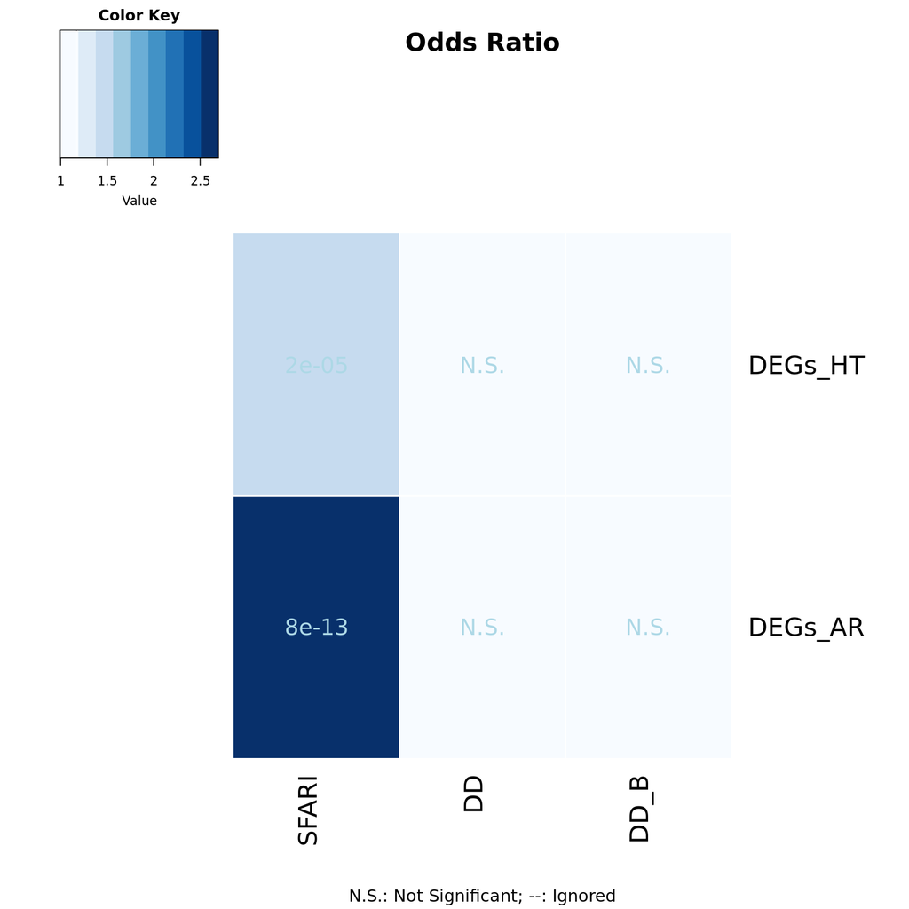

```r
drawHeatmap(OvObj, cutoff=0.05, note.col='lightblue', grid.col = 'Blues')
```

### 6.2 DotPlot

```r
OR <- data.frame(getMatrix(OvObj, name='odds.ratio'))
OR$Module <- row.names(OR)
OR <- gather(OR, 'KBase', 'OR', -Module)

PVAL <- data.frame(getMatrix(OvObj, name='pval'))
PVAL$Module <- row.names(PVAL)
PVAL <- gather(PVAL, 'KBase', 'PVal', -Module)

NUM <- data.frame(getMatrix(OvObj, name='intersection'))
NUM$Module <- row.names(NUM)
NUM <- gather(NUM, 'KBase', 'Numbers', -Module)


if(! identical(OR$Module, PVAL$Module)){
  stop('Inconsistency')
}
if(! identical(OR$Module, NUM$Module)){
  stop('Inconsistency')
}
if(! identical(OR$KBase, NUM$KBase)){
  stop('Inconsistency')
}
if(! identical(OR$KBase, NUM$KBase)){
  stop('Inconsistency')
}


Res <- mutate(OR, Pval=PVAL$PVal) %>% mutate(Numbers=NUM$Numbers)

OR
NUM
```

[output not shown]

```r
ResSel <- dplyr::filter(Res, OR > 1)

max(ResSel$OR)
```

```
## [1] 2.696243
```

```r
max(-log10(ResSel$Pval))
```

```
## [1] 12.10073
```

```r
ResSel %>% dplyr::filter(Pval < 0.05)
```

[output not shown]

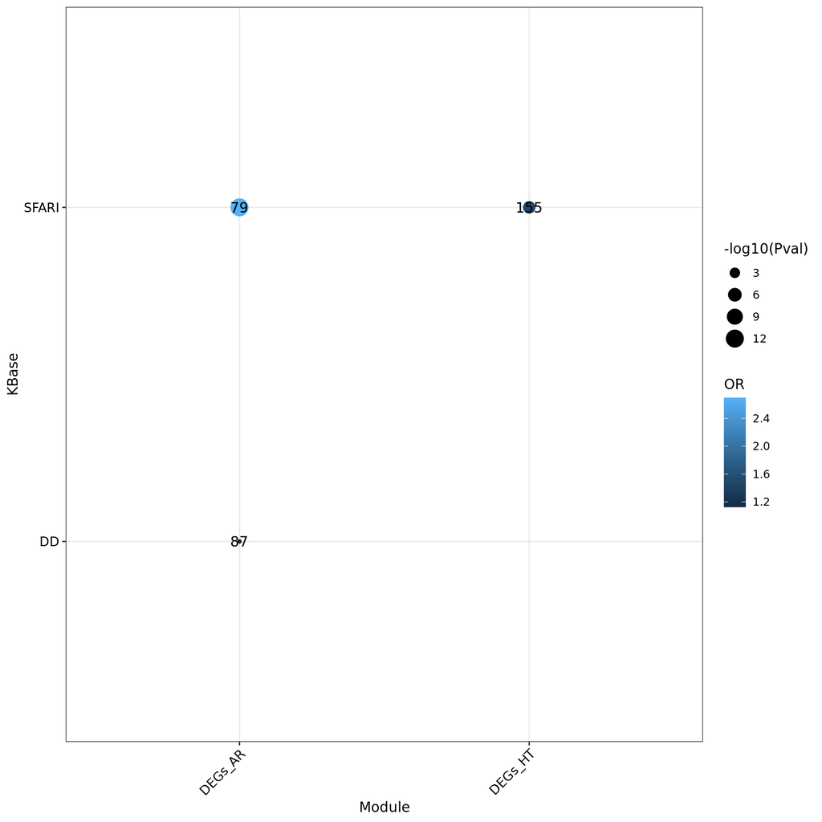

```r
cols <- viridis::cividis(100)[20:100]

Dot <- ggplot(ResSel, aes(Module, KBase, label=Numbers)) +
  geom_point(aes(size=-log10(Pval), col=OR)) +
  geom_text() +
  #scale_size_continuous(range=c(5, 20), limits=c(-log10(0.05), 10)) +
  #scale_color_viridis_c(limits=c(1, 2), begin=0.4) + xlab('') + ylab('') +
  theme_bw() +
  theme(axis.text.x = element_text(angle = 45, vjust = 1, hjust=1)) +
  theme(axis.text = element_text(size=10, color='black'))

Dot
```

```r
ggsave(Dot, filename=paste0(params$FiguresFolder, 'KB_NDD_day50.pdf'), width=6.5, height=6.5)
```

## 7. Overlapping gene identity

### Heterozygous

- For **SFARI 155 overlapping genes**: ABCA7, ADAMTS18, ADARB1, AFF2, ANKS1B, APP, ARHGAP11B, ARHGAP15, ARHGEF10, ASPM, ATP2B2, BCL2, BDNF, BICDL1, BRCA2, CACNA1C, CACNA1D, CACNA1E, CACNA1G, CACNA1H, CACNA1I, CACNA2D3, CADM1, CBLN1, CCNG1, CDH11, CDH13, CDH8, CHD5, CLSTN2, CNTN5, CNTNAP5, CPEB4, CSMD1, DAGLA, DGKK, DIAPH3, DLGAP1, DLGAP2, DLX1, DLX2, DNER, DOCK1, DOCK4, DPP10, DPP4, EBF3, EN2, EPHA6, EPPK1, ESRRB, FABP3, FABP5, FABP7, FGFBP3, FGFR2, FOXP2, GABBR2, GALNT14, GATM, GPC4, GPD2, GPR85, GRIA1, GRID1, GRIK4, GRIN1, GRIN2B, GRM4, GSN, HECW2, HIVEP3, HLA-A, HLA-B, HOMER1, HTR1B, INPP1, IQGAP3, IQSEC2, IRF2BPL, ITGA4, JAKMIP1, KCND3, KCNMA1, KCNQ3, KCNT1, KHDRBS2, KIF14, KIF21B, KIRREL3, KIT, LAMB1, LRFN5, MAL, MAOA, MAPK3, MCM4, MDGA2, MEGF11, MSN, MYO5C, MYT1L, NFIA, NFIB, NR3C2, NRG1, NRP2, NTNG1, NTRK3, OPHN1, PATJ, PAX5, PCDH10, PCDH19, PCDH8, PCDH9, PCDHA1, PCDHA10, PCDHA2, PCDHA3, PCDHA6, PCDHA7, PCDHAC2, PCDHGA11, PLCB1, PLXNA4, PRKCB, PTPRT, RASSF5, RBFOX1, RBMS3, RPP25, SAMD11, SCN1A, SH3KBP1, SHOX, SLC16A3, SLC16A7, SLC30A3, SLC4A10, SLC6A1, SLC7A5, SPARCL1, ST8SIA2, SYN1, SYN3, SYT17, SYT3, TBX1, TH, THRA, TPO, TSHZ3, TUBGCP5, ZNF713
- For **ADHD 138 overlapping genes**: ACSL4, ADARB1, ADGRG1, AFF2, AFF3, ALDH1A3, ASCC3, ASPM, BCOR, BLM, BRCA1, BUB1B, CACNA1A, CACNA1D, CACNA1E, CACNA1G, CACNA1H, CAMK2B, CCNA2, CDC45, CDC6, CDT1, CENPF, CEP83, CHD5, CKAP2L, CLN6, CNKSR1, COASY, COL18A1, COL9A3, CPS1, DHFR, DMD, EBF3, ENTPD1, EPHB4, ESCO2, FAM20C, FDFT1, FOXP2, FRMPD4, GABBR2, GAMT, GATM, GLI2, GLI3, GMNN, GNAO1, GPC4, GRIA1, GRIN1, GRIN2B, HCN1, HECW2, HPDL, HYLS1, IQSEC2, IRF2BPL, IRX5, KCNA4, KCNJ8, KCNK9, KCNMA1, KCNT1, KIF11, KIF14, KIF1A, KIF4A, KIRREL3, KLF8, LAMB1, MAB21L1, MAF, MAOA, MAT1A, MGP, MIR17HG, MLC1, MMADHC, MYCN, NCAPD2, NCAPG2, NCAPH, NDE1, NEDD4L, NFIA, NFIB, NFIX, NTNG2, OPHN1, ORC1, PAX6, PAX8, PCDH19, PDE10A, PDGFRB, PHOX2B, PLCB1, PLK4, PLP1, PURA, PUS7, RAD51, RBFOX1, RIMS2, RNASEH2B, RORA, SCN1A, SEMA3A, SIX3, SLC2A1, SLC39A8, SLC4A4, SLC6A1, SLC6A17, SLC6A9, SMOC1, SOX10, SOX11, SOX6, SRPX2, STIL, STRA6, SUMF1, SYN1, TBX1, TH, THRA, TMEM63A, TOE1, TRAIP, TREX1, TRIP13, TRNT1, WDR62, WNT4, ZNF713

#### SFARI

```r
overlapSFARI_1 <- paste0(sort(intersect(DEA$DEGs_HT, GeneVect$SFARI)))
print('Genes present in the overlap for SFARI:')
```

```
## [1] "Genes present in the overlap for SFARI:"
```

```r
DT::datatable(as.data.frame(overlapSFARI_1), class = "hover", colnames = "",
              escape = FALSE, caption = "Heterozygous (SFARI)",
              options = list(autoWidth = TRUE, dom = "Bfrtip"))
```

| 1 | ABCA7 |
| --- | --- |
| 2 | ADAMTS18 |
| 3 | ADARB1 |
| 4 | AFF2 |
| 5 | ANKS1B |
| 6 | APP |
| 7 | ARHGAP11B |
| 8 | ARHGAP15 |
| 9 | ARHGEF10 |
| 10 | ASPM |

[output cut: 145 more lines]

#### ADHD

```r
overlapADHD_1 <- paste0(sort(intersect(DEA$DEGs_HT, GeneVect$DD_B)))
print('Gene present in the overlap for ADHD:')
```

```
## [1] "Gene present in the overlap for ADHD:"
```

```r
DT::datatable(as.data.frame(overlapADHD_1), class = "hover", colnames = "",
              escape = FALSE, caption = "Heterozygous (ADHD)",
              options = list(autoWidth = TRUE, dom = "Bfrtip"))
```

| 1 | ACSL4 |
| --- | --- |
| 2 | ADARB1 |
| 3 | ADGRG1 |
| 4 | AFF2 |
| 5 | AFF3 |
| 6 | ALDH1A3 |
| 7 | ASCC3 |
| 8 | ASPM |
| 9 | BCOR |
| 10 | BLM |

[output cut: 128 more lines]

### Ancestral

- For **SFARI 79 overlapping genes**: AMT, ANKS1B, ARHGAP24, BCL11A, CACNA1C, CACNA1E, CACNA1I, CACNA2D1, CACNA2D3, CACNB2, CADPS, CBLN1, CDH11, CDH9, CELF4, CELF6, CHD5, CHRM3, CNTN5, CNTNAP5, DNER, DPP10, DSCAM, EBF3, FGFR2, FOXP2, GABBR2, GABRQ, GLRA2, GPR85, GRIK2, GRIN1, GRIN2B, GRM4, GRM5, HIVEP3, HS3ST5, JAKMIP1, KCND2, KCND3, KCNQ3, KIT, LAMA1, LRFN5, MYT1L, NEGR1, NFIB, NRXN1, NTRK3, NXPH1, P2RX4, PCDH10, PCDH9, PCDHA10, PCDHA13, PCDHA2, PCDHA3, PCDHA4, PCDHA5, PCDHA6, PCDHA7, PLPPR4, POLA2, PTPRT, RAPGEF4, RBMS3, ROBO2, SCN1A, SCN2A, SEMA5A, SLC16A3, SLC1A1, SLC6A1, SNAP25, SYN1, SYN2, SYN3, SYT3, ZBTB16
- For **ADHD 46 overlapping genes**: ACTL6B, AMT, ATP8A2, BCL11A, CACNA1A, CACNA1E, CAMK2B, CHD5, COL18A1, CPS1, EBF3, EEF1A2, FGF14, FOXP2, GABBR2, GMNN, GRIA3, GRIA4, GRIK2, GRIN1, GRIN2B, GRM1, HYLS1, KCNA2, LAMA1, MLC1, NALCN, NFIB, NRXN1, PRSS12, PUS7, RORA, RYR3, SCN1A, SCN2A, SLC6A1, SLC6A17, SLC6A9, SMOC1, SNAP25, SPTBN4, STRA6, SYN1, TRNT1, TUBB4A, ZBTB16

#### SFARI

```r
overlapSFARI_2 <- paste0(sort(intersect(DEA$DEGs_AR, GeneVect$SFARI)))
print('Genes present in the overlap for SFARI:')
```

```
## [1] "Genes present in the overlap for SFARI:"
```

```r
DT::datatable(as.data.frame(overlapSFARI_2), class = "hover", colnames = "",
              escape = FALSE, caption = "Ancestral (SFARI)",
              options = list(autoWidth = TRUE, dom = "Bfrtip"))
```

| 1 | AMT |
| --- | --- |
| 2 | ANKS1B |
| 3 | ARHGAP24 |
| 4 | BCL11A |
| 5 | CACNA1C |
| 6 | CACNA1E |
| 7 | CACNA1I |
| 8 | CACNA2D1 |
| 9 | CACNA2D3 |
| 10 | CACNB2 |

[output cut: 69 more lines]

#### ADHD

```r
overlapADHD_2 <- paste0(sort(intersect(DEA$DEGs_AR, GeneVect$DD_B)))
print('Gene present in the overlap for ADHD:')
```

```
## [1] "Gene present in the overlap for ADHD:"
```

```r
DT::datatable(as.data.frame(overlapADHD_2), class = "hover", colnames = "",
              escape = FALSE, caption = "Ancestral (ADHD)",
              options = list(autoWidth = TRUE, dom = "Bfrtip"))
```

| 1 | ACTL6B |
| --- | --- |
| 2 | AMT |
| 3 | ATP8A2 |
| 4 | BCL11A |
| 5 | CACNA1A |
| 6 | CACNA1E |
| 7 | CAMK2B |
| 8 | CHD5 |
| 9 | COL18A1 |
| 10 | CPS1 |

[output cut: 36 more lines]

## 8. Savings

```r
saveRDS(Res, paste0(params$SavingFolder, 'day50_NDDOverlapResults.rds'))
```

```r
SessionInfo <- sessionInfo()
Date <- date()
save.image(paste0(params$SavingFolder, 'KB_NDD_day50.RData'))
```

```r
Date
```

```
## [1] "Fri Jan 10 21:10:29 2025"
```

```r
SessionInfo
```

### **last update on: Fri Jan 10 21:13:00 2025**